# Bank Customer Churn Prediction - EDA

## Libraries dependence

```python
import pandas as pd
import numpy as np

# Matplotlib for visualization
from matplotlib import pyplot as plt
# display plots in the notebook
%matplotlib inline

# Seaborn for easier visualization
import seaborn as sns
sns.set_style('darkgrid')

# store elements as dictionary keys and their counts as dictionary values
from collections import Counter

import warnings
```

## Data Source

Kaggle - Churn Modelling Calssification Data Set

- This data set contains details of a bank's customers and the target variable is a binary variable reflecting the fact whether the customer left the bank (closed his account) or he continues to be a customer.
- It consists of 10,000 records with demographic and bank history information from customers from three countries, France, Germany and Spain.

```python
#Exploratory Analysis

#Read the CSV and Perform Basic Data Cleaning
```

```python
#Load the dataset
df = pd.read_csv("Bank Churn Modelling.csv")
print(f"Dataframe dimensions: {df.shape}")
df.head()
```

```
Dataframe dimensions: (10000, 13)
```

|  | CustomerId | Surname | CreditScore | Geography | Gender | Age | Tenure | Balance | Num Of Products | Has Credit Card | Is Active Member | Estimated Salary | Churn |
| --- | --- | --- | --- | --- | --- | --- | --- | --- | --- | --- | --- | --- | --- |
| 0 | 15634602 | Hargrave | 619 | France | Female | 42 | 2 | 0.00 | 1 | 1 | 1 | 101348.88 | 1 |
| 1 | 15647311 | Hill | 608 | Spain | Female | 41 | 1 | 83807.86 | 1 | 0 | 1 | 112542.58 | 0 |
| 2 | 15619304 | Onio | 502 | France | Female | 42 | 8 | 159660.80 | 3 | 1 | 0 | 113931.57 | 1 |
| 3 | 15701354 | Boni | 699 | France | Female | 39 | 1 | 0.00 | 2 | 0 | 0 | 93826.63 | 0 |
| 4 | 15737888 | Mitchell | 850 | Spain | Female | 43 | 2 | 125510.82 | 1 | 1 | 1 | 79084.10 | 0 |

```python
df.info()
```

```
<class 'pandas.core.frame.DataFrame'>
RangeIndex: 10000 entries, 0 to 9999
Data columns (total 13 columns):
 #   Column            Non-Null Count  Dtype
---  ------            --------------  -----
 0   CustomerId        10000 non-null  int64
 1   Surname           10000 non-null  object
 2   CreditScore       10000 non-null  int64
 3   Geography         10000 non-null  object
 4   Gender            10000 non-null  object
 5   Age               10000 non-null  int64
 6   Tenure            10000 non-null  int64
 7   Balance           10000 non-null  float64
 8   Num Of Products   10000 non-null  int64
 9   Has Credit Card   10000 non-null  int64
 10  Is Active Member  10000 non-null  int64
 11  Estimated Salary  10000 non-null  float64
 12  Churn             10000 non-null  int64
dtypes: float64(2), int64(8), object(3)
memory usage: 1015.8+ KB
```

```python
# List number of unique customer IDs
df.CustomerId.nunique()
```

```
10000
```

All Cusuomer IDs are unique --> that also means no duplicates

```python
df.duplicated().sum()
```

```
0
```

# Unused Features

====>> To make dataframe easily readable we will drop features not needed for machine learning <<====

- CustomerId
- Surname

```python
# Drop unused features
df.drop(['CustomerId', 'Surname'], axis=1, inplace=True)
print(f"Dataframe dimensions: {df.shape}")
df.head()
```

```
Dataframe dimensions: (10000, 11)
```

|  | CreditScore | Geography | Gender | Age | Tenure | Balance | Num Of Products | Has Credit Card | Is Active Member | Estimated Salary | Churn |
| --- | --- | --- | --- | --- | --- | --- | --- | --- | --- | --- | --- |
| 0 | 619 | France | Female | 42 | 2 | 0.00 | 1 | 1 | 1 | 101348.88 | 1 |
| 1 | 608 | Spain | Female | 41 | 1 | 83807.86 | 1 | 0 | 1 | 112542.58 | 0 |
| 2 | 502 | France | Female | 42 | 8 | 159660.80 | 3 | 1 | 0 | 113931.57 | 1 |
| 3 | 699 | France | Female | 39 | 1 | 0.00 | 2 | 0 | 0 | 93826.63 | 0 |
| 4 | 850 | Spain | Female | 43 | 2 | 125510.82 | 1 | 1 | 1 | 79084.10 | 0 |

```python
df.isnull().sum()
```

```
CreditScore         0
Geography           0
Gender              0
Age                 0
Tenure              0
Balance             0
Num Of Products     0
Has Credit Card     0
Is Active Member    0
Estimated Salary    0
Churn               0
dtype: int64
```

### Distributions of Numeric Features

#### Plotting Histogram grid

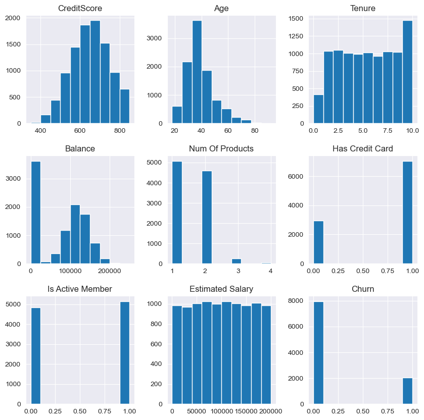

```python
# Plot histogram grid
df.hist(figsize=(10,10))
plt.show()
```

### Summary statistics for the numeric features

```python
# Summarize numerical features
df.describe()
```

|  | CreditScore | Age | Tenure | Balance | Num Of Products | Has Credit Card | Is Active Member | Estimated Salary | Churn |
| --- | --- | --- | --- | --- | --- | --- | --- | --- | --- |
| count | 10000.000000 | 10000.000000 | 10000.000000 | 10000.000000 | 10000.000000 | 10000.00000 | 10000.000000 | 10000.000000 | 10000.000000 |
| mean | 650.528800 | 38.921800 | 5.012800 | 76485.889288 | 1.530200 | 0.70550 | 0.515100 | 100090.239881 | 0.203700 |
| std | 96.653299 | 10.487806 | 2.892174 | 62397.405202 | 0.581654 | 0.45584 | 0.499797 | 57510.492818 | 0.402769 |
| min | 350.000000 | 18.000000 | 0.000000 | 0.000000 | 1.000000 | 0.00000 | 0.000000 | 11.580000 | 0.000000 |
| 25% | 584.000000 | 32.000000 | 3.000000 | 0.000000 | 1.000000 | 0.00000 | 0.000000 | 51002.110000 | 0.000000 |
| 50% | 652.000000 | 37.000000 | 5.000000 | 97198.540000 | 1.000000 | 1.00000 | 1.000000 | 100193.915000 | 0.000000 |
| 75% | 718.000000 | 44.000000 | 7.000000 | 127644.240000 | 2.000000 | 1.00000 | 1.000000 | 149388.247500 | 0.000000 |
| max | 850.000000 | 92.000000 | 10.000000 | 250898.090000 | 4.000000 | 1.00000 | 1.000000 | 199992.480000 | 1.000000 |

From the summary statistics and the histograms we can conclude that all features look OK. We do not see any extreme values for any feature.

### Distributions of Categorical Features

```python
# Summarize categorical features
df.describe(include=["object"])
```

|  | Geography | Gender |
| --- | --- | --- |
| count | 10000 | 10000 |
| unique | 3 | 2 |
| top | France | Male |
| freq | 5014 | 5457 |

This shows us the number of unique classes for each feature. For example, there are more males (5457) than females. And France is most common of 3 geographies in our dataframe. There are no sparse classes.

#### Let's visualize this information

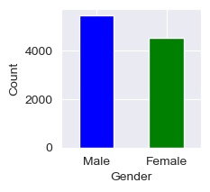

```
Counter({'Female': 4543, 'Male': 5457})
```

```python
# Bar plot for "Gender"
plt.figure(figsize=(2,2))
df['Gender'].value_counts().plot.bar(color=['b','g'])
plt.ylabel('Count')
plt.xlabel('Gender')
plt.xticks(rotation=0)
plt.show()

# Display count of each class
Counter(df.Gender)
```

In our data sample there are more males than females.

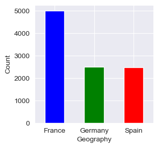

```
Counter({'France': 5014, 'Spain': 2477, 'Germany': 2509})
```

```python
# Bar plot for "Geography"
plt.figure(figsize=(3,3))
df['Geography'].value_counts().plot.bar(color=['b','g','r'])
plt.ylabel('Count')
plt.xlabel('Geography')
plt.xticks(rotation=0)
plt.show()

# Display count of each class
Counter(df.Geography)
```

Majority of customers are from France, about 50%, and from Germany and Spain around 25% each

### Churn Segmentation by Gender

```python
# Segment "Churn" by gender and display the frequency and percentage within each class
grouped = df.groupby('Gender')['Churn'].agg(Count='value_counts')
grouped
```

| Gender | Churn | Count |
| --- | --- | --- |
| Female | 0 | 3404 |
|  | 1 | 1139 |
| Male | 0 | 4559 |
|  | 1 | 898 |

```python
# Reorganize dataframe for plotting count
dfgc = grouped
dfgc = dfgc.pivot_table(values = 'Count', index = 'Gender', columns = ['Churn'])
dfgc
```

| Churn Gender | 0 | 1 |
| --- | --- | --- |
| Female | 3404 | 1139 |
| Male | 4559 | 898 |

```python
# Calculate percentage within each class
dfgp = grouped.groupby(level=[0]).apply(lambda g: round(g * 100 / g.sum(), 2))
dfgp.rename(columns={'Count' : 'Percentage'}, inplace = True)
dfgp
```

| Gender | Churn | Percentage |
| --- | --- | --- |
| Female | 0 | 74.93 |
|  | 1 | 25.07 |
| Male | 0 | 83.54 |
|  | 1 | 16.46 |

```python
# Reorganize dataframe for plotting percentage
dfgp = dfgp.pivot_table(values='Percentage', index='Gender', columns=['Churn'])
dfgp
```

| Churn Gender | 0 | 1 |
| --- | --- | --- |
| Female | 74.93 | 25.07 |
| Male | 83.54 | 16.46 |

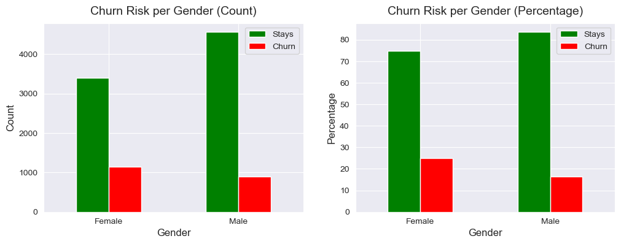

```python
# Churn distribution by gender, count + percentage

labels= ['Stays', 'Churn']

fig, (ax1, ax2) = plt.subplots(1, 2, figsize=(12, 4))

dfgc.plot(kind='bar',
          color=['g', 'r'],
          rot=0,
          ax=ax1)
ax1.legend(labels)
ax1.set_title('Churn Risk per Gender (Count)', fontsize=14, pad=10)
ax1.set_ylabel('Count',size=12)
ax1.set_xlabel('Gender', size=12)


dfgp.plot(kind='bar',
          color=['g', 'r'],
          rot=0,
          ax=ax2)
ax2.legend(labels)
ax2.set_title('Churn Risk per Gender (Percentage)', fontsize=14, pad=10)
ax2.set_ylabel('Percentage',size=12)
ax2.set_xlabel('Gender', size=12)

plt.show()
```

In percentage females are more likely to leave the bank; 25% comparing to males, 16%.

### Churn Segmentation by Geography

```python
# Segment "Exited" by geography and display the frequency and percentage within each class
grouped = df.groupby('Geography')['Churn'].agg(Count='value_counts')
grouped
```

| Geography | Churn | Count |
| --- | --- | --- |
| France | 0 | 4204 |
|  | 1 | 810 |
| Germany | 0 | 1695 |
|  | 1 | 814 |
| Spain | 0 | 2064 |
|  | 1 | 413 |

```python
# Reorganize dataframe for plotting count
dfgeoc = grouped
dfgeoc = dfgeoc.pivot_table(values='Count', index='Geography', columns=['Churn'])
dfgeoc
```

| Churn Geography | 0 | 1 |
| --- | --- | --- |
| France | 4204 | 810 |
| Germany | 1695 | 814 |
| Spain | 2064 | 413 |

```python
# Calculate percentage within each class
dfgeop = grouped.groupby(level=[0]).apply(lambda g: round(g * 100 / g.sum(), 2))
dfgeop.rename(columns={'Count': 'Percentage'}, inplace=True)
dfgeop
```

| Geography | Churn | Percentage |
| --- | --- | --- |
| France | 0 | 83.85 |
|  | 1 | 16.15 |
| Germany | 0 | 67.56 |
|  | 1 | 32.44 |
| Spain | 0 | 83.33 |
|  | 1 | 16.67 |

```python
# Reorganize dataframe for plotting percentage
dfgeop = dfgeop.pivot_table(values='Percentage', index='Geography', columns=['Churn'])
dfgeop
```

| Churn Geography | 0 | 1 |
| --- | --- | --- |
| France | 83.85 | 16.15 |
| Germany | 67.56 | 32.44 |
| Spain | 83.33 | 16.67 |

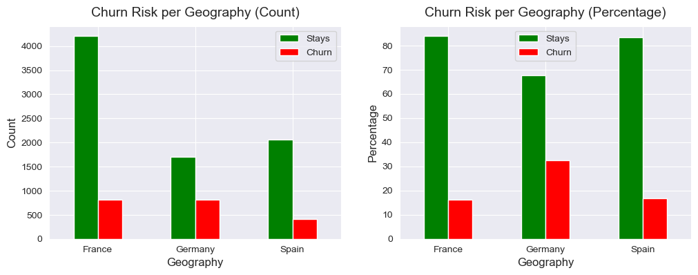

```python
# Churn distribution by geography, count + percentage

labels= ['Stays', 'Churn']

fig, (ax1, ax2) = plt.subplots(1, 2, figsize=(12, 4))

dfgeoc.plot(kind='bar',
          color=['g', 'r'],
          rot=0,
          ax=ax1)
ax1.legend(labels)
ax1.set_title('Churn Risk per Geography (Count)', fontsize=14, pad=10)
ax1.set_ylabel('Count',size=12)
ax1.set_xlabel('Geography', size=12)


dfgeop.plot(kind='bar',
          color=['g', 'r'],
          rot=0,
          ax=ax2)
ax2.legend(labels)
ax2.set_title('Churn Risk per Geography (Percentage)', fontsize=14, pad=10)
ax2.set_ylabel('Percentage',size=12)
ax2.set_xlabel('Geography', size=12)

plt.show()
```

## Correlations

```python
# Calculate correlations between numeric features
correlations = df.corr()

# sort features in order of their correlation with "Exited"
sort_corr_cols = correlations.Churn.sort_values(ascending=False).keys()
sort_corr = correlations.loc[sort_corr_cols,sort_corr_cols]
sort_corr
```

|  | Churn | Age | Balance | Estimated Salary | Has Credit Card | Tenure | CreditScore | Num Of Products | Is Active Member |
| --- | --- | --- | --- | --- | --- | --- | --- | --- | --- |
| Churn | 1.000000 | 0.285323 | 0.118533 | 0.012097 | -0.007138 | -0.014001 | -0.027094 | -0.047820 | -0.156128 |
| Age | 0.285323 | 1.000000 | 0.028308 | -0.007201 | -0.011721 | -0.009997 | -0.003965 | -0.030680 | 0.085472 |
| Balance | 0.118533 | 0.028308 | 1.000000 | 0.012797 | -0.014858 | -0.012254 | 0.006268 | -0.304180 | -0.010084 |
| Estimated Salary | 0.012097 | -0.007201 | 0.012797 | 1.000000 | -0.009933 | 0.007784 | -0.001384 | 0.014204 | -0.011421 |
| Has Credit Card | -0.007138 | -0.011721 | -0.014858 | -0.009933 | 1.000000 | 0.022583 | -0.005458 | 0.003183 | -0.011866 |
| Tenure | -0.014001 | -0.009997 | -0.012254 | 0.007784 | 0.022583 | 1.000000 | 0.000842 | 0.013444 | -0.028362 |
| CreditScore | -0.027094 | -0.003965 | 0.006268 | -0.001384 | -0.005458 | 0.000842 | 1.000000 | 0.012238 | 0.025651 |
| Num Of Products | -0.047820 | -0.030680 | -0.304180 | 0.014204 | 0.003183 | 0.013444 | 0.012238 | 1.000000 | 0.009612 |
| Is Active Member | -0.156128 | 0.085472 | -0.010084 | -0.011421 | -0.011866 | -0.028362 | 0.025651 | 0.009612 | 1.000000 |

Let's use Seaborn's .heatmap() function to visualize the correlation grid.

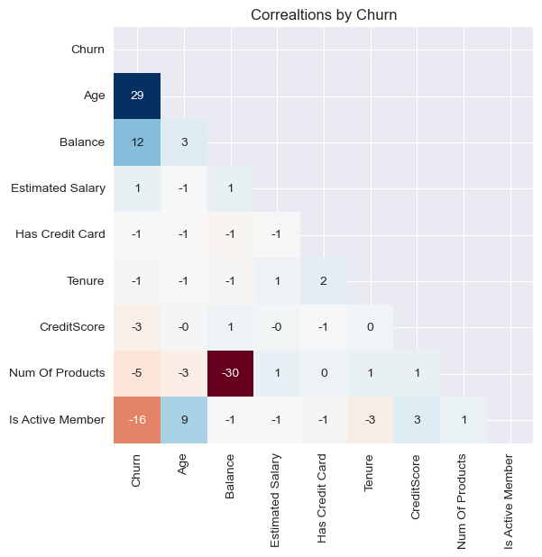

```python
# Generate a mask for the upper triangle
corr_mask = np.zeros_like(correlations)
corr_mask[np.triu_indices_from(corr_mask)] = 1

# Make the figsize 6X6
plt.figure(figsize = (6,6))

# Plot heatmap of annotated correlations; change background to white
##with sns.axes_style('white'):
sns.heatmap(sort_corr*100,
           cmap='RdBu',
           annot=True,
           fmt='.0f',
           mask=corr_mask,
           cbar=False)

plt.title('Correaltions by Churn', fontsize=12)
plt.yticks(rotation=0)
plt.show()
```

Very weak correlations in general. Only weak positive correlation with age, very weak positive correlation with balance, and very weak negative correlations with number of products and membership

## Pairplot

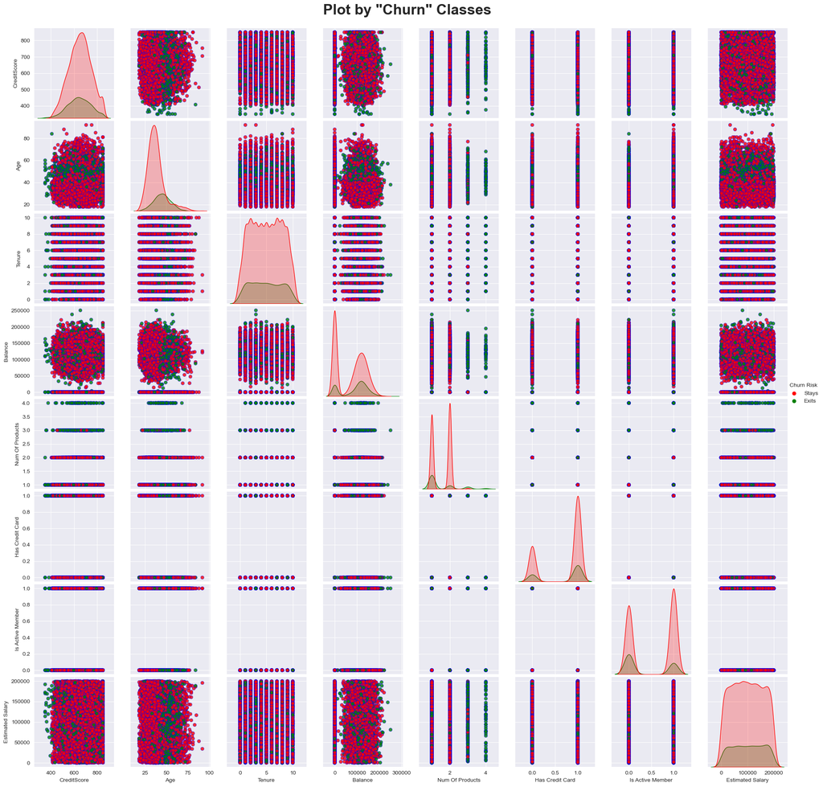

```python
# Plot Seaborn's pairplot
g = sns.pairplot(df, hue='Churn',
                 palette={1 : 'green',
                          0 : 'red'},
                 plot_kws={'alpha' : 0.8, 'edgecolor' : 'b', 'linewidth' : 0.5})

fig = g.fig
fig.subplots_adjust(top=0.95, wspace=0.2)
fig.suptitle('Plot by "Churn" Classes',
             fontsize=26,
             fontweight='bold')


# Update the legend
new_title = 'Churn Risk'
g._legend.set_title(new_title)
# replace labels
new_labels = ['Stays', 'Exits']
for t, l in zip(g._legend.texts, new_labels): t.set_text(l)

plt.show()
```

The density plots on the diagonal make it easier to compare these distributions. We can notice that only few features have slightly different distributions. For example, from the density plot for Age, it could be seen that older people have slightly higher tendecy to leave the bank.

Let’s reduce the clutter by plotting only four features:

- Age,
- Is Active Member,
- Num Of Products
- Balance

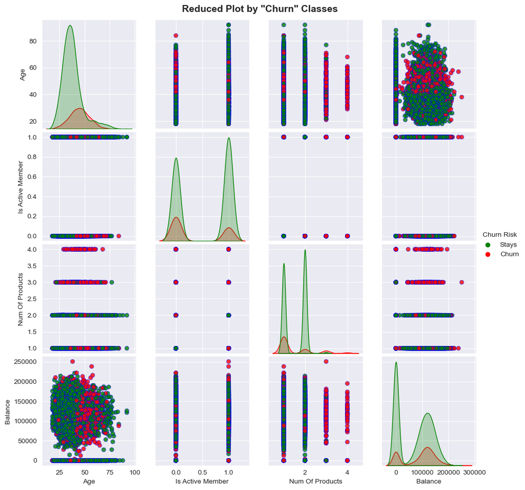

```python
# Plot Seaborn's pairplot
g = sns.pairplot(df, hue='Churn',
                 vars=['Age', 'Is Active Member', 'Num Of Products', 'Balance'], # reduce to less features
                 palette={0 : 'green',
                          1 : 'red'},
                 plot_kws={'alpha' : 0.8, 'edgecolor' : 'b', 'linewidth' : 0.5})

fig = g.fig
fig.subplots_adjust(top=0.95, wspace=0.2)
fig.suptitle('Reduced Plot by "Churn" Classes',
             fontsize=14,
             fontweight='bold')

# Update the legend
new_title = 'Churn Risk'
g._legend.set_title(new_title)
# replace labels
new_labels = ['Stays', 'Churn']
for t, l in zip(g._legend.texts, new_labels): t.set_text(l)

plt.show()
```

### Violin Plots

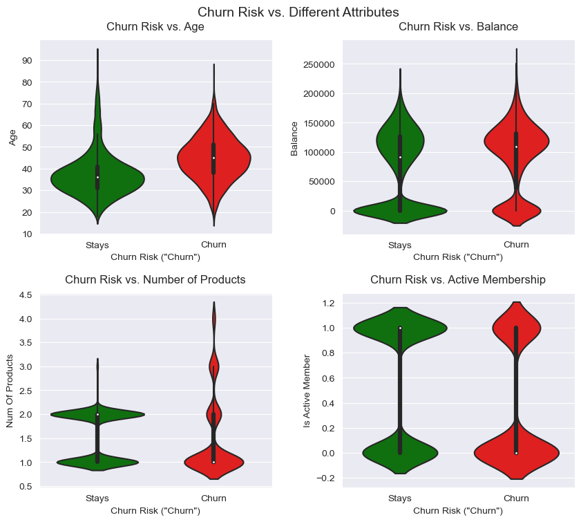

```python
# Segment age by Churn and plot distributions
#  “categorical” variable Churn is a numeric
#  for plotting purposes only we will change it to real categorical variable

# Define palette
my_pal = {'Stays': 'green', 'Churn': 'red'}
# Convert to categorical
hr = {0: 'Stays', 1: 'Churn'}
churn = df['Churn'].map(hr)

fig, ((ax1, ax2), (ax3, ax4)) = plt.subplots(2, 2, figsize=(10, 8))
fig.suptitle('Churn Risk vs. Different Attributes', fontsize=14)
fig.subplots_adjust(top=0.92, wspace=0.3, hspace=0.3)

sns.violinplot(x=churn,
               y=df['Age'],
               order=['Stays', 'Churn'],
               palette=my_pal,
               ax=ax1)

ax1.set_title('Churn Risk vs. Age', fontsize=12, pad=10)
ax1.set_ylabel('Age',size=10)
ax1.set_xlabel('Churn Risk ("Churn")', size=10)

sns.violinplot(x=churn,
               y=df['Balance'],
               order=['Stays', 'Churn'],
               palette=my_pal,
               ax=ax2)

ax2.set_title('Churn Risk vs. Balance', fontsize=12, pad=10)
ax2.set_ylabel('Balance',size=10)
ax2.set_xlabel('Churn Risk ("Churn")', size=10)

sns.violinplot(x=churn,
               y=df['Num Of Products'],
               order=['Stays', 'Churn'],
               palette=my_pal,
               ax=ax3)

ax3.set_title('Churn Risk vs. Number of Products', fontsize=12, pad=10)
ax3.set_ylabel('Num Of Products',size=10)
ax3.set_xlabel('Churn Risk ("Churn")', size=10)

sns.violinplot(x=churn,
               y=df['Is Active Member'],
               order=['Stays', 'Churn'],
               palette=my_pal,
               ax=ax4)

ax4.set_title('Churn Risk vs. Active Membership', fontsize=12, pad=10)
ax4.set_ylabel('Is Active Member',size=10)
ax4.set_xlabel('Churn Risk ("Churn")', size=10)
plt.show()
```

```python
# Define our target variable
y = df.Churn
```

```python
y.shape
```

```
(10000,)
```

Let's define a small helper funtcion which displays count and percentage per class of the target feature.

```python
# Function to display count and percentage per class of target feature
def class_count(a):
    counter=Counter(a)
    kv=[list(counter.keys()),list(counter.values())]
    dff = pd.DataFrame(np.array(kv).T, columns=['Churn','Count'])
    dff['Count'] = dff['Count'].astype('int64')
    dff['%'] = round(dff['Count'] / a.shape[0] * 100, 2)
    return dff.sort_values('Count',ascending=False)
```

```python
# Let's use the function
dfcc = class_count(y)
dfcc
```

|  | Churn | Count | % |
| --- | --- | --- | --- |
| 1 | 0 | 7963 | 79.63 |
| 0 | 1 | 2037 | 20.37 |

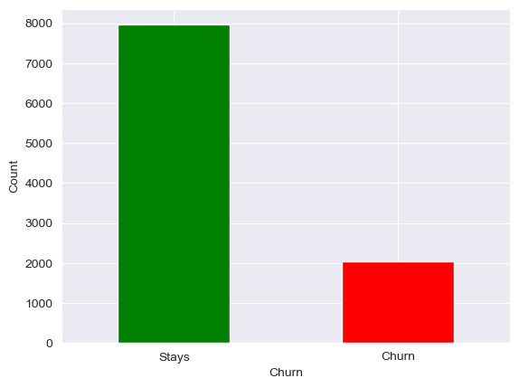

```python
# Plot distribution of target variable, Exited column

labels=['Stays', 'Churn']
dfcc.plot.bar(x='Churn', y='Count', color=['g', 'r'], legend=False)
plt.xticks(dfcc['Churn'], labels, rotation=0)
plt.ylabel('Count')
plt.show()
```

We can see that our dataset is imbalanced. The majority class, "Stays" (0), has around 80% data points and the minority class, "Churn" (1), has around 20% datapoints.

To address this, in our machine learning algorithms we will use SMOTE (Synthetic Minority Over-sampling Technique).

### Finalizing the Dataframe

```python
df.head()
```

|  | CreditScore | Geography | Gender | Age | Tenure | Balance | Num Of Products | Has Credit Card | Is Active Member | Estimated Salary | Churn |
| --- | --- | --- | --- | --- | --- | --- | --- | --- | --- | --- | --- |
| 0 | 619 | France | Female | 42 | 2 | 0.00 | 1 | 1 | 1 | 101348.88 | 1 |
| 1 | 608 | Spain | Female | 41 | 1 | 83807.86 | 1 | 0 | 1 | 112542.58 | 0 |
| 2 | 502 | France | Female | 42 | 8 | 159660.80 | 3 | 1 | 0 | 113931.57 | 1 |
| 3 | 699 | France | Female | 39 | 1 | 0.00 | 2 | 0 | 0 | 93826.63 | 0 |
| 4 | 850 | Spain | Female | 43 | 2 | 125510.82 | 1 | 1 | 1 | 79084.10 | 0 |

```python
df.info()
```

```
<class 'pandas.core.frame.DataFrame'>
RangeIndex: 10000 entries, 0 to 9999
Data columns (total 11 columns):
 #   Column            Non-Null Count  Dtype
---  ------            --------------  -----
 0   CreditScore       10000 non-null  int64
 1   Geography         10000 non-null  object
 2   Gender            10000 non-null  object
 3   Age               10000 non-null  int64
 4   Tenure            10000 non-null  int64
 5   Balance           10000 non-null  float64
 6   Num Of Products   10000 non-null  int64
 7   Has Credit Card   10000 non-null  int64
 8   Is Active Member  10000 non-null  int64
 9   Estimated Salary  10000 non-null  float64
 10  Churn             10000 non-null  int64
dtypes: float64(2), int64(7), object(2)
memory usage: 859.5+ KB
```

Our dataframe looks good and it is ready to be saved.

### Save the dataframe as the analytical base table

```python
# Save analytical base table
### df.to_csv('ELCOT\Desktop\csv file_base_table.csv', index=None)
```